# Transformations & Weighted Least Squares

- We have been working with *linear* regression models so far in the course.
- Some models are nonlinear, but can be *transformed* to a linear model.
- We will also see that transformations can sometimes *stabilize* the variance making constant variance a more reasonable assumption.
- Finally, we will see how to correct for unequal variance using a technique weighted least squares (WLS).

```r
options(repr.plot.width=4, repr.plot.height=4)
```

## Bacterial colony decay

Here is a simple dataset showing the number of bacteria alive in a colony, $N_t$ as a function of time $t$. A simple linear regression model is clearly not a very good fit.

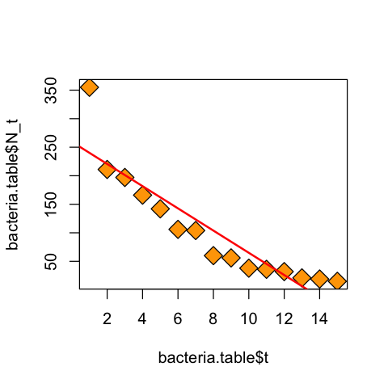

```r
bacteria.table = read.table('http://stats191.stanford.edu/data/bacteria.table', header=T)
plot(bacteria.table$t, bacteria.table$N_t, pch=23, cex=2, bg='orange')
bacteria.lm = lm(N_t ~ t, bacteria.table)
abline(bacteria.lm$coef, lwd=2, col='red')
```

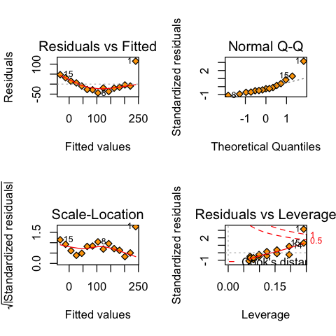

```r
par(mfrow=c(2,2))
plot(bacteria.lm, pch=23, bg='orange')
```

## Exponential decay model

- Suppose the expected number of cells grows like $$E(n_t) = n_0 e^{\beta_1t}, \qquad t=1, 2, 3, \dots$$
- If we take logs of both sides $$\log E(n_t) = \log n_0 + \beta_1 t.$$
- A reasonable (?) model: $$\log n_t = \log n_0 + \beta_1 t + \varepsilon_t, \qquad \varepsilon_t \overset{IID}{\sim} N(0,\sigma^2).$$

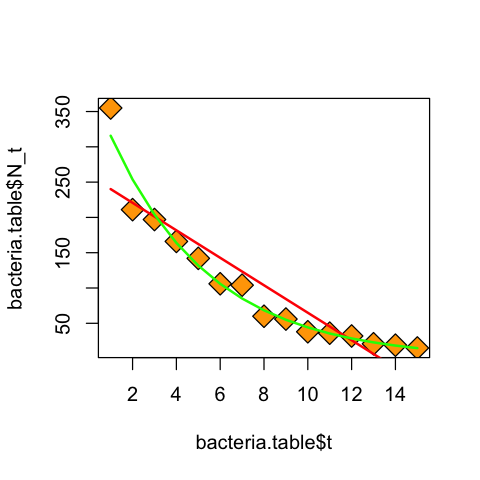

```r
bacteria.log.lm <- lm(log(N_t) ~ t, bacteria.table)
plot(bacteria.table$t, bacteria.table$N_t, pch=23, cex=2, bg='orange')
lines(bacteria.table$t, fitted(bacteria.lm), lwd=2, col='red')
lines(bacteria.table$t, exp(fitted(bacteria.log.lm)), lwd=2, col='green')
```

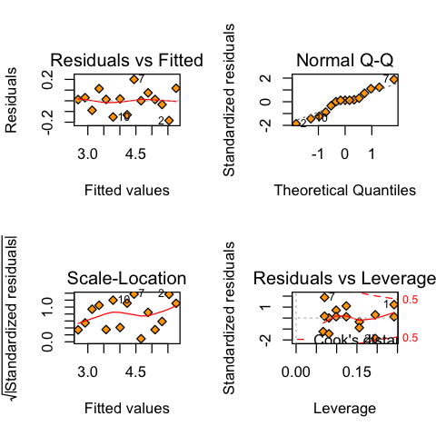

```r
par(mfrow=c(2,2))
plot(bacteria.log.lm, pch=23, bg='orange')
```

### Logarithmic transformation

- This model slightly different than original model: $$E(\log n_t) \leq \log E(n_t)$$ but may be approximately true.
- If $\varepsilon_t \sim N(0,\sigma^2)$ then $$n_t = n_0 \cdot \gamma_t \cdot e^{\beta_1 t}.$$
- $\gamma_t=e^{\varepsilon_t}$ is called a log-normal $(0,\sigma^2)$ random variable.

## Linearizing regression function

We see that an exponential growth or decay model can be made (approximately) linear. Here are a few other models that can be linearized:

- $y=\alpha x^{\beta}$, use $\tilde{y}=\log(y), \tilde{x}=\log(x)$;
- $y=\alpha e^{\beta x}$, use $\tilde{y}=\log(y)$;
- $y=x/(\alpha x - \beta)$, use $\tilde{y}=1/y, \tilde{x}=1/x$.
- More in textbook.

### Caveats

- Just because expected value linearizes, doesn’t mean that the errors behave correctly.
- In some cases, this can be corrected using weighted least squares (more later).
- Constant variance, normality assumptions should still be checked.

## Stabilizing variance

- Sometimes, a transformation can turn non-constant variance errors to "close to" constant variance. This is another situation in which we might consider a transformation.
- Example: by the "delta rule", if $$\text{Var}(Y) = \sigma^2 E(Y)$$ then $$\text{Var}(\sqrt{Y}) \simeq \frac{\sigma^2}{4}.$$
- In practice, we might not know which transformation is best. [Box-Cox transformations](http://en.wikipedia.org/wiki/Power_transform) offer a tool to find a "best" transformation.

## Delta rule

The following approximation is ubiquitous in statistics.

- Taylor series expansion: $$f(Y) = f(E(Y)) + \dot{f}(E(Y)) (Y - E(Y)) + \dots$$
- Taking expectations of both sides yields: $$\text{Var}(f(Y)) \simeq \dot{f}(E(Y))^2 \cdot \text{Var}(Y)$$

## Delta rule

- So, for our previous example: $$\text{Var}(\sqrt{Y}) \simeq \frac{\text{Var}(Y)}{4 \cdot E(Y)}$$
- Another example $$\text{Var}(\log(Y)) \simeq \frac{\text{Var}(Y)}{E(Y)^2}.$$

### Caveats

- Just because a transformation makes variance constant doesn’t mean regression function is still linear (or even that it was linear)!
- The models are approximations, and once a model is selected our standard diagnostics should be used to assess adequacy of fit.
- It is possible to have non-constant variance but the variance stabilizing transformation may destroy linearity of the regression function.
  - *Solution:* try weighted least squares (WLS).

## Correcting for unequal variance: weighted least squares

- We will now see an example in which there seems to be strong evidence for variance that changes based on `Region`.
- After observing this, we will create a new model that attempts to *correct* for this and come up with better estimates.
- *Correcting* for unequal variance, as we describe it here, generally requires a model for how the variance depends on observable quantities.

## Correcting for unequal variance: weighted least squares

| **Variable** | **Description** |
| --- | --- |
| $Y$ | Per capita education expenditure by state |
| $X_1$ | Per capita income in 1973 by state |
| $X_2$ | Proportion of population under 18 |
| $X_3$ | Proportion in urban areas |
| `Region` | Which region of the country are the states located in |

```r
education.table = read.table('http://stats191.stanford.edu/data/education1975.table', header=T)
education.table$Region = factor(education.table$Region)
education.lm = lm(Y ~ X1 + X2 + X3, data=education.table)
summary(education.lm)
```

```
Call:
lm(formula = Y ~ X1 + X2 + X3, data = education.table)

Residuals:
    Min      1Q  Median      3Q     Max
-84.878 -26.878  -3.827  22.246  99.243

Coefficients:
              Estimate Std. Error t value Pr(>|t|)
(Intercept) -5.566e+02  1.232e+02  -4.518 4.34e-05 ***
X1           7.239e-02  1.160e-02   6.239 1.27e-07 ***
X2           1.552e+00  3.147e-01   4.932 1.10e-05 ***
X3          -4.269e-03  5.139e-02  -0.083    0.934
---
Signif. codes:  0 ‘***’ 0.001 ‘**’ 0.01 ‘*’ 0.05 ‘.’ 0.1 ‘ ’ 1

Residual standard error: 40.47 on 46 degrees of freedom
Multiple R-squared:  0.5913,	Adjusted R-squared:  0.5647
F-statistic: 22.19 on 3 and 46 DF,  p-value: 4.945e-09
```

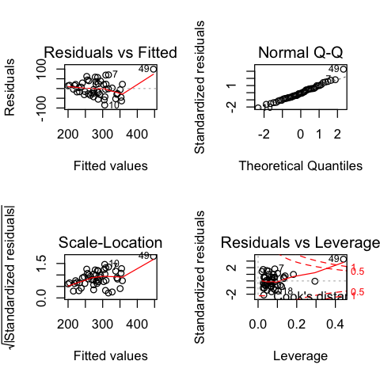

```r
par(mfrow=c(2,2))
plot(education.lm)
```

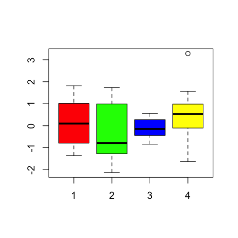

```r
boxplot(rstandard(education.lm) ~ education.table$Region,
        col=c('red', 'green', 'blue', 'yellow'))
```

```r
keep.subset = (education.table$STATE != 'AK')
education.noAK.lm = lm(Y ~ X1 + X2 + X3, subset=keep.subset,
                       data=education.table)
summary(education.noAK.lm)
```

```
Call:
lm(formula = Y ~ X1 + X2 + X3, data = education.table, subset = keep.subset)

Residuals:
    Min      1Q  Median      3Q     Max
-81.128 -22.154  -7.542  22.542  80.890

Coefficients:
              Estimate Std. Error t value Pr(>|t|)
(Intercept) -277.57731  132.42286  -2.096 0.041724 *
X1             0.04829    0.01215   3.976 0.000252 ***
X2             0.88693    0.33114   2.678 0.010291 *
X3             0.06679    0.04934   1.354 0.182591
---
Signif. codes:  0 ‘***’ 0.001 ‘**’ 0.01 ‘*’ 0.05 ‘.’ 0.1 ‘ ’ 1

Residual standard error: 35.81 on 45 degrees of freedom
Multiple R-squared:  0.4967,	Adjusted R-squared:  0.4631
F-statistic:  14.8 on 3 and 45 DF,  p-value: 7.653e-07
```

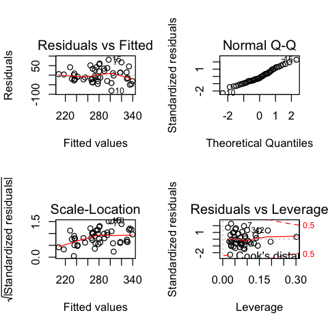

```r
par(mfrow=c(2,2))
plot(education.noAK.lm)
```

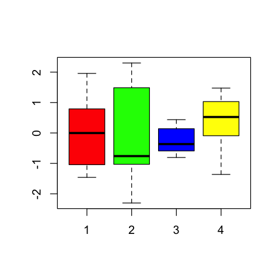

```r
par(mfrow=c(1,1))
boxplot(rstandard(education.noAK.lm) ~ education.table$Region[keep.subset],
        col=c('red', 'green', 'blue', 'yellow'))
```

## Reweighting observations

- If you have a reasonable guess of variance as a function of the predictors, you can use this to *reweight* the data.
- Hypothetical example $$Y_i = \beta_0 + \beta_1 X_i + \varepsilon_i, \qquad \varepsilon_i \sim N(0,\sigma^2 X_i^2).$$
- Setting $\tilde{Y}_i = Y_i / X_i$, $\tilde{X}_i = 1 / X_i$, model becomes $$\tilde{Y}_i = \beta_0 \tilde{X}_i + \beta_1 + \gamma_i, \gamma_i \sim N(0,\sigma^2).$$

## Weighted Least Squares

- Fitting this model is equivalent to minimizing $$\sum_{i=1}^n \frac{1}{X_i^2} \left(Y_i - \beta_0 - \beta_1 X_i\right)^2$$
- Weighted Least Squares $$SSE(\beta, w) = \sum_{i=1}^n w_i \left(Y_i - \beta_0 - \beta_1 X_i\right)^2, \qquad w_i = \frac{1}{X_i^2}.$$
- In general, weights should be like: $$w_i = \frac{1}{\text{Var}(\varepsilon_i)}.$$
- Our education expenditure example assumes $$ w_i = W_{\tt Region[i]} $$

## What if we didn't reweight?

- Our (ordinary) least squares estimator with design matrix $X$ is $$ \hat{\beta} =\hat{\beta}_{OLS} = (X^TX)^{-1}X^TY = \beta + (X^TX)^{-1}X^T\epsilon. $$
- Our model says that $\varepsilon | X \sim N(0, \sigma^2X)$ so $$ \begin{aligned} E[(X^TX)^{-1}X^T\epsilon] &= E[(X^TX)^{-1}X^T\epsilon|X] \\ &= 0 \end{aligned} $$ So the **OLS estimator is unbiased.**
- Variance of $\hat{\beta}_{OLS}$ is $$ \text{Var}((X^TX)^{-1}X^T\epsilon) = \sigma^2 (X^TX)^{-1}X^TVX (X^TX)^{-1}, \qquad V =\text{diag}(X_1^2, \dots, X_n^2) $$

## Common weighting schemes

- If you have a qualitative variable, then it is easy to estimate weight within groups (our example today).
- "Often" $$\text{Var}(\varepsilon_i) = \text{Var}(Y_i) = V(E(Y_i))$$
- Many non-Gaussian (non-Normal) models behave like this: logistic, Poisson regression.

## Two stage procedure

- Suppose we have a hypothesis about the weights, i.e. they are constant within Region, or they are something like $$w_i^{-1} = \text{Var}(\epsilon_i) = \alpha_0 + \alpha_1 X_{i1}^2.$$
- We pre-whiten:
  1. Fit model using OLS (Ordinary Least Squares) to get initial estimate $\widehat{\beta}_{OLS}$
  2. Use predicted values from this model to estimate $w_i$.
  3. Refit model using WLS (Weighted Least Squares).
  4. If needed, iterate previous two steps.

```r
educ.weights = 0 * education.table$Y
for (region in levels(education.table$Region)) {
  subset.region = (education.table$Region[keep.subset] == region)
  educ.weights[subset.region] <- 1.0 / (sum(resid(education.noAK.lm)
                                            [subset.region]^2) /
                                        sum(subset.region))
}
```

```r
unique(educ.weights)
```

1. 0.00068912628894633

2. 0.000410344340187708

3. 0.00400908850190692

4. 0.00105216278017872

Here is our new model. Note that the scale of the estimates is *unchanged*. Numerically the estimates are similar. What changes most is the `Std. Error` column.

```r
education.noAK.weight.lm <- lm(Y ~ X1 + X2 + X3,
                               weights=educ.weights,
                               subset=keep.subset,
                               data=education.table)
summary(education.noAK.weight.lm)
```

```
Call:
lm(formula = Y ~ X1 + X2 + X3, data = education.table, subset = keep.subset,
    weights = educ.weights)

Weighted Residuals:
     Min       1Q   Median       3Q      Max
-1.69882 -0.71382 -0.07928  0.79298  1.86328

Coefficients:
              Estimate Std. Error t value Pr(>|t|)
(Intercept) -3.181e+02  7.833e+01  -4.060 0.000193 ***
X1           6.245e-02  7.867e-03   7.938 4.24e-10 ***
X2           8.791e-01  2.003e-01   4.388 6.83e-05 ***
X3           2.981e-02  3.421e-02   0.871 0.388178
---
Signif. codes:  0 ‘***’ 0.001 ‘**’ 0.01 ‘*’ 0.05 ‘.’ 0.1 ‘ ’ 1

Residual standard error: 0.984 on 45 degrees of freedom
Multiple R-squared:  0.7566,	Adjusted R-squared:  0.7404
F-statistic: 46.63 on 3 and 45 DF,  p-value: 7.41e-14
```

```r
summary(education.noAK.lm)
```

```
Call:
lm(formula = Y ~ X1 + X2 + X3, data = education.table, subset = keep.subset)

Residuals:
    Min      1Q  Median      3Q     Max
-81.128 -22.154  -7.542  22.542  80.890

Coefficients:
              Estimate Std. Error t value Pr(>|t|)
(Intercept) -277.57731  132.42286  -2.096 0.041724 *
X1             0.04829    0.01215   3.976 0.000252 ***
X2             0.88693    0.33114   2.678 0.010291 *
X3             0.06679    0.04934   1.354 0.182591
---
Signif. codes:  0 ‘***’ 0.001 ‘**’ 0.01 ‘*’ 0.05 ‘.’ 0.1 ‘ ’ 1

Residual standard error: 35.81 on 45 degrees of freedom
Multiple R-squared:  0.4967,	Adjusted R-squared:  0.4631
F-statistic:  14.8 on 3 and 45 DF,  p-value: 7.653e-07
```

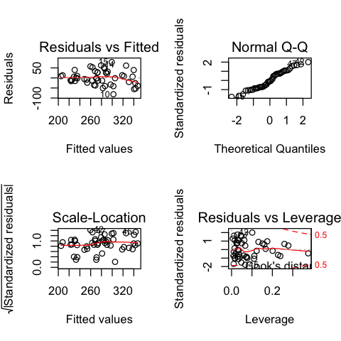

```r
par(mfrow=c(2,2))
plot(education.noAK.weight.lm)
```

Let's look at the boxplot again. It looks better, but perhaps not perfect.

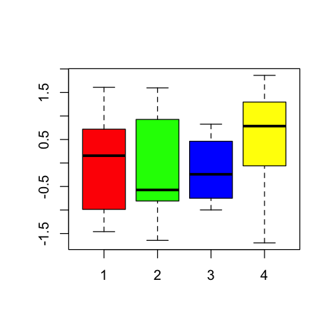

```r
par(mfrow=c(1,1))
boxplot(resid(education.noAK.weight.lm, type='pearson') ~ education.table$Region[keep.subset],
        col=c('red', 'green', 'blue', 'yellow'))
```

## Unequal variance: effects on inference

- So far, we have just mentioned that things *may* have unequal variance, but not thought about how it affects inference.
- In general, if we ignore unequal variance, our estimates of variance are not very good. The covariance has the “sandwich form” we saw above $$\text{Cov}(\widehat{\beta}_{OLS}) = (X'X)^{-1}(X'W^{-1}X)(X'X)^{-1}.$$ with $W=\text{diag}(1/\sigma^2_i)$.
- **If our `Std. Error` is incorrect, so are our conclusions based on $t$-statistics!**
- In this example, correcting for weights seemed to make the $t$-statistics larger. **This will not always be the case!**

## Unequal variance: effects on inference

- Weighted least squares estimator $$ \hat{\beta}_{WLS} = (X^TWX)^{-1}X^TWY $$
- If we have the correct weights, then $$ \text{Cov}(\widehat{\beta}_{WLS}) = (X^TWX)^{-1}. $$

## Efficiency

- The efficiency of an unbiased estimator of $\beta$ is 1 / variance.
- Estimators can be compared by their efficiency: the more efficient, the better.
- The other reason to correct for unequal variance (besides so that we get valid inference) is for efficiency.

## Illustrative example

- Suppose $$Z_i = \mu + \varepsilon_i, \qquad \varepsilon_i \sim N(0, i^2 \cdot \sigma^2), 1 \leq i \leq n.$$
- Three unbiased estimators of $\mu$: $$\begin{aligned} \widehat{\mu}_1 &= \frac{1}{n}\sum_{i=1}^n Z_i \\ \widehat{\mu}_2 &= \frac{1}{\sum_{i=1}^n i^{-2}}\sum_{i=1}^n i^{-2}Z_i \\ \widehat{\mu}_3 &= \frac{1}{\sum_{i=1}^n i^{-1}}\sum_{i=1}^n i^{-1}Z_i \\ \end{aligned}$$

## Illustrative example

- The estimator $\widehat{\mu}_2$ will always have lower variance, hence tighter confidence intervals.
- The estimator $\widehat{\mu}_3$ has incorrect weights, but they are "closer" to correct than the naive mean's weights which assume each observation has equal variance.

```r
ntrial = 1000   # how many trials will we be doing?
nsample = 20   # how many points in each trial
sd = c(1:20)   # how does the variance change
mu = 2.0

get.sample <- function() {
  return(rnorm(nsample)*sd + mu)
}

unweighted.estimate <- function(cur.sample) {
  return(mean(cur.sample))
}

unweighted.estimate <- numeric(ntrial)
weighted.estimate <- numeric(ntrial)
suboptimal.estimate <- numeric(ntrial)
```

Let's simulate a number of experiments and compare the three estimates.

```r
for (i in 1:ntrial) {
  cur.sample = get.sample()
  unweighted.estimate[i] = mean(cur.sample)
  weighted.estimate[i] = sum(cur.sample/sd^2) / sum(1/sd^2)
  suboptimal.estimate[i] = sum(cur.sample/sd) / sum(1/sd)
}

data.frame(mean(unweighted.estimate),
           sd(unweighted.estimate))
data.frame(mean(weighted.estimate),
           sd(weighted.estimate))
data.frame(mean(suboptimal.estimate),
           sd(suboptimal.estimate))
```

| mean.unweighted.estimate. | sd.unweighted.estimate. |
| --- | --- |
| 1.909851 | 2.730319 |

| mean.weighted.estimate. | sd.weighted.estimate. |
| --- | --- |
| 1.970648 | 0.7775003 |

| mean.suboptimal.estimate. | sd.suboptimal.estimate. |
| --- | --- |
| 1.953418 | 1.256637 |

```r
densY = c(density(unweighted.estimate)$y, density(weighted.estimate)$y, density(suboptimal.estimate)$y)
densX = c(density(unweighted.estimate)$x, density(weighted.estimate)$x, density(suboptimal.estimate)$x)
options(repr.plot.width=5, repr.plot.height=5)
```

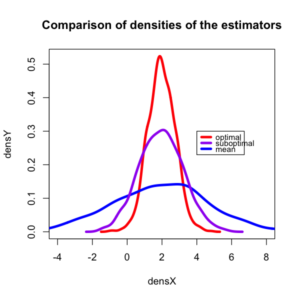

```r
plot(densX, densY, type='n', main='Comparison of densities of the estimators', cex=0.8, xlim=c(-4, 8))
lines(density(weighted.estimate), col='red', lwd=4)
lines(density(unweighted.estimate), col='blue', lwd=4)
lines(density(suboptimal.estimate), col='purple', lwd=4)
legend(4,0.3, c('optimal', 'suboptimal', 'mean'), col=c('red', 'purple', 'blue'), lwd=rep(4,3), cex=0.8)
```